# STAIML ASSIGNMENT 2

NAME:LOCHAN PAUDEL PRN: 23070126170 BRANCH:AIML(A3) BATCH:2023-27

```python
import numpy as np
import pandas as pd
import matplotlib.pyplot as plt
import seaborn as sns
from sklearn.model_selection import train_test_split
from sklearn.linear_model import LinearRegression
from sklearn.metrics import mean_squared_error, r2_score
from sklearn.preprocessing import StandardScaler

# Read the data files
df_mat = pd.read_csv(r"C:\Users\DELL\OneDrive\Desktop\student\student-mat.csv")
```

a)Identify which features have null values? How will you address the null values in different features?

```python
print("Features with null values:")
print(df_mat.isnull().sum())
```

```
Features with null values:
school;sex;age;address;famsize;Pstatus;Medu;Fedu;Mjob;Fjob;reason;guardian;traveltime;studytime;failures;schoolsup;famsup;paid;activities;nursery;higher;internet;romantic;famrel;freetime;goout;Dalc;Walc;health;absences;G1;G2;G3    0
dtype: int64
```

b) What transformations might be necessary for categorical variables such as 'school', 'sex', 'address', 'famsize', and 'reason' before applying linear regression?

```python
data = pd.get_dummies(df_mat, columns=['school', 'sex', 'address', 'famsize', 'reason'])
```

c) Considering the numeric attributes like 'age', 'absences', and 'G1', 'G2' grades, would you perform any normalization or scaling before fitting a linear regression model? If yes, what method would you choose and why?

```python
scaler = StandardScaler()
df_mat[['age', 'absences', 'G1', 'G2']] = scaler.fit_transform(df_mat[['age', 'absences', 'G1', 'G2']])
```

d) Which features have outliers present? How will you address those?

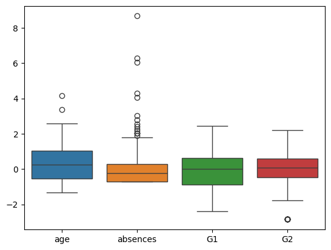

```python
sns.boxplot(data=df_mat[['age', 'absences', 'G1', 'G2']])
plt.show()
```

e) Would you create any new features (feature engineering) from existing ones, such as combining parental education levels into a single feature or creating a feature representing total alcohol consumption?

```python
df_mat['parent_education'] = df_mat['Medu'] + df_mat['Fedu']
df_mat['total_alcohol'] = df_mat['Dalc'] + df_mat['Walc']
```

f) Which features will you select for prediction of final grades (G3) and how?

```python
selected_features = ['age', 'absences', 'G1', 'G2', 'parent_education', 'total_alcohol', 'studytime']
X = df_mat[selected_features]
y = df_mat['G3']
```

g) Since 'G1' and 'G2' grades are highly correlated with 'G3', would you consider dropping any of them to avoid multicollinearity in the linear regression model? If yes, which one and why?

```python
corr_matrix = df_mat[['G1', 'G2', 'G3']].corr()
print(corr_matrix)
```

```
          G1        G2        G3
G1  1.000000  0.852118  0.801468
G2  0.852118  1.000000  0.904868
G3  0.801468  0.904868  1.000000
```

```python
X_train, X_test, y_train, y_test = train_test_split(X, y, test_size=0.2, random_state=42)
lr = LinearRegression()
lr.fit(X_train, y_train)
y_pred = lr.predict(X_test)
```

h) How would you evaluate the performance of the linear regression model in predicting 'G3' grades? Which metrics would you use, and why are they appropriate for this task

```python
print("Mean Squared Error:", mean_squared_error(y_test, y_pred))
print("R sq. Score:", r2_score(y_test, y_pred))
```

```
Mean Squared Error: 4.233848546253576
R sq. Score: 0.7935216392869646
```